# Homework 10

Agnieszka Sitko

```r
library(lattice)
library(PBImisc)
library(agricolae)
library(dplyr)
eunomia <- eunomia
```

In this homework I will analyze EUNOMIA study trying to find relation between BPRS level type of detected disorder (in accordance to ICD code). I will use `BPRS.T3` variable which stands for the third measure of the Average score for Brief Psychiatric Rating Scale of a patient.

### Analyzing fixed effect of `ICD10`

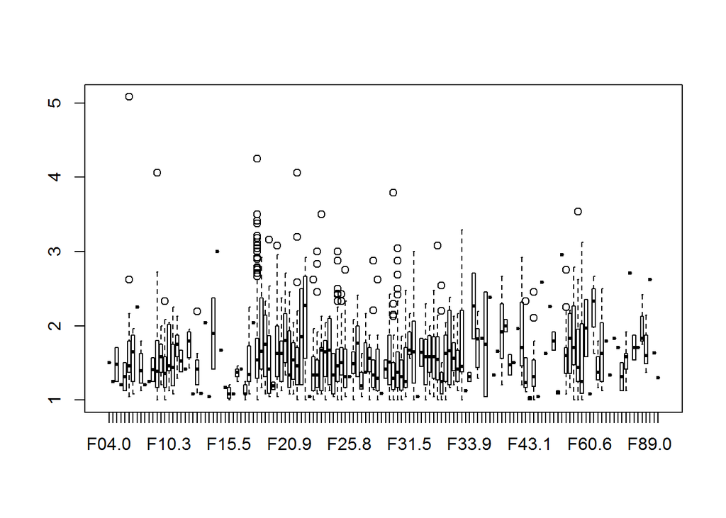

```r
boxplot(BPRS.T3 ~ ICD10, data = eunomia)
```

Because of the high number of `ICD10` classes, it is hard to decide bazing on the boxplot only if means of `BPRS.T3` in some groups are significantally different than means in other groups. Let’s perform some tests.

```r
fixedModel <- lm(BPRS.T3 ~ NUM.HOSP + ICD10, data = eunomia)
tail(scheffe.test(aov(fixedModel), 'ICD10', console = FALSE)$groups)
```

```
##       trt    means M
## 133 F60.6 1.083333 a
## 134 F31.7 1.043478 a
## 135 F13.4 1.041667 a
## 136 F23.  1.041667 a
## 137 F44.5 1.041667 a
## 138 F43.1 1.020833 a
```

If we code `ICD10` as a fixed component of a model, we can simply use Scheffe post-hoc test to cluster `ICD10` depending on an avarage level of `BPRS.T3`. In this case it turns out that all groups of `ICD10` belong to the same group (I have printed only the tail of Scheffe test results).

### Analyzing mixed effect of `ICD10`

If we treat `ICD10` as a random component, we should not be interested in an impact of a particular group of `ICD10` on the dependent variable. Thus, clustering would be impossible to do.

```r
mixedModel <- lmer(BPRS.T3 ~ NUM.HOSP + (1|ICD10), data = eunomia, REML = FALSE)
summary(mixedModel)$varcor
```

```
##  Groups   Name        Std.Dev.
##  ICD10    (Intercept) 0.071442
##  Residual             0.429676
```

However, we can test if `ICD10` has an impact on `BPRS.T3` at all. To do so, I will use permutation test. According to the analysis presented above and low level of `ICD10` random effect variance we may cosider the situation that `ICD10` is not important in our model. If that is true, we will cluster all levels of `ICD10` into one group.

```r
N = 1000
eunomia2 = eunomia

logs = replicate(N, {
      eunomia2$ICD10 <- sample(eunomia2$ICD10)
      logLik(lmer(BPRS.T3 ~ NUM.HOSP + (1|ICD10), data = eunomia2, REML = FALSE))
      })

(sum(logs > logLik(mixedModel))) / N
```

```
## [1] 0
```

The above number shows the fraction of models with permutated `ICD10` which were better than the model without permutations (taking into account likelihood). Because the number is lower than 0.05, we say that `ICD10` is important. Therefore, we cannot cluster `ICD10` into one group.